# 03-People Adipiz

Alonso Pizarro Lagunas

29/10/2021

# Ejemplo color de pelos y ojos

- La tabla *HairEyeColor* tiene datos agregados.

```r
HairEyeColor
```

```
, , Sex = Male

       Eye
Hair    Brown Blue Hazel Green
  Black    32   11    10     3
  Brown    53   50    25    15
  Red      10   10     7     7
  Blond     3   30     5     8

, , Sex = Female

       Eye
Hair    Brown Blue Hazel Green
  Black    36    9     5     2
  Brown    66   34    29    14
  Red      16    7     7     7
  Blond     4   64     5     8
```

```r
sum(HairEyeColor) -> total
```

El total de individuos de la tabla de datos es 592

- Ahora podemos calcular las frecuencias relativas marginales

```r
prop.table(HairEyeColor, margin = 3)
```

```
, , Sex = Male

       Eye
Hair          Brown        Blue       Hazel       Green
  Black 0.114695341 0.039426523 0.035842294 0.010752688
  Brown 0.189964158 0.179211470 0.089605735 0.053763441
  Red   0.035842294 0.035842294 0.025089606 0.025089606
  Blond 0.010752688 0.107526882 0.017921147 0.028673835

, , Sex = Female

       Eye
Hair          Brown        Blue       Hazel       Green
  Black 0.115015974 0.028753994 0.015974441 0.006389776
  Brown 0.210862620 0.108626198 0.092651757 0.044728435
  Red   0.051118211 0.022364217 0.022364217 0.022364217
  Blond 0.012779553 0.204472843 0.015974441 0.025559105
```

```r
prop.table(HairEyeColor, margin = c(1,2))
```

```
, , Sex = Male

       Eye
Hair        Brown      Blue     Hazel     Green
  Black 0.4705882 0.5500000 0.6666667 0.6000000
  Brown 0.4453782 0.5952381 0.4629630 0.5172414
  Red   0.3846154 0.5882353 0.5000000 0.5000000
  Blond 0.4285714 0.3191489 0.5000000 0.5000000

, , Sex = Female

       Eye
Hair        Brown      Blue     Hazel     Green
  Black 0.5294118 0.4500000 0.3333333 0.4000000
  Brown 0.5546218 0.4047619 0.5370370 0.4827586
  Red   0.6153846 0.4117647 0.5000000 0.5000000
  Blond 0.5714286 0.6808511 0.5000000 0.5000000
```

- Cambiando el orden de la tabla con la función `aperm()`

```r
aperm(HairEyeColor, perm = c("Sex", "Hair", "Eye"))
```

```
, , Eye = Brown

        Hair
Sex      Black Brown Red Blond
  Male      32    53  10     3
  Female    36    66  16     4

, , Eye = Blue

        Hair
Sex      Black Brown Red Blond
  Male      11    50  10    30
  Female     9    34   7    64

, , Eye = Hazel

        Hair
Sex      Black Brown Red Blond
  Male      10    25   7     5
  Female     5    29   7     5

, , Eye = Green

        Hair
Sex      Black Brown Red Blond
  Male       3    15   7     8
  Female     2    14   7     8
```

- Importando la librería `kable`

```r
library(kableExtra)
kable(HairEyeColor)
```

[output not shown]

```
- Otra librería para manejar tablas `xtable`
```

```r
library(xtable)
sex = factor(c("H","M","M","M","H","H","M","M"))
ans = factor(c("S","N","S","S","S","N","N","S"))

xtable(table(sex,ans))
```

[output not shown]

# Diagrama de barras

El **diagrama de barras** es el tipo de gráfico más usado para representar variables cualitativas, en donde para cada nivel de la variable cualitativa hay una barra con su frecuencia dentro de esa variable.

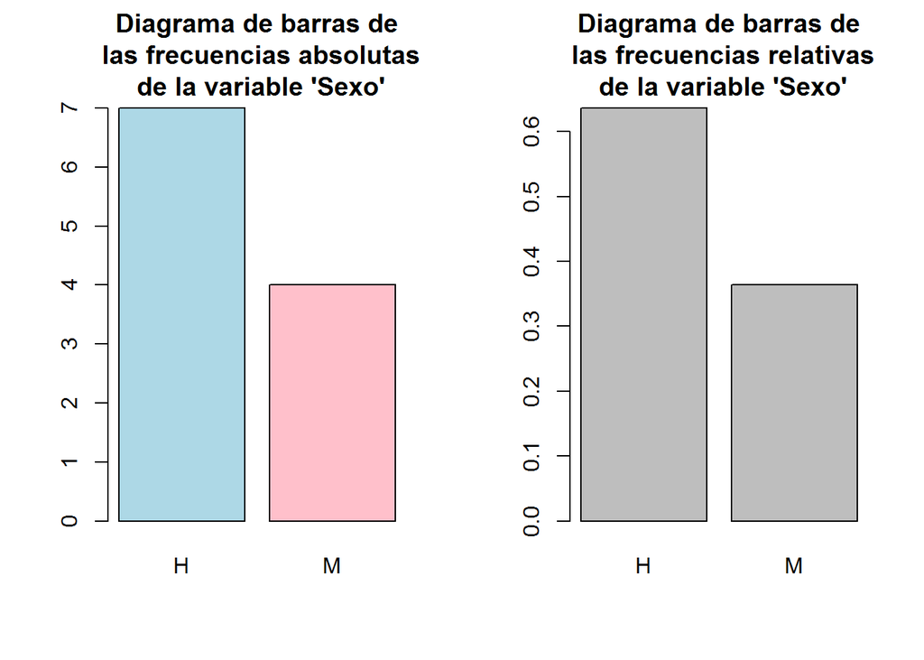

```r
par(mfrow = c(1,2))

Sex = sample(c("H","M"), 11, replace = TRUE)
barplot(table(Sex), col = c("lightblue", "pink"), main ="Diagrama de barras de\n las frecuencias absolutas\n de la variable 'Sexo'")


barplot(prop.table(table(Sex)), main ="Diagrama de barras de\n las frecuencias relativas\n de la variable 'Sexo'")
```

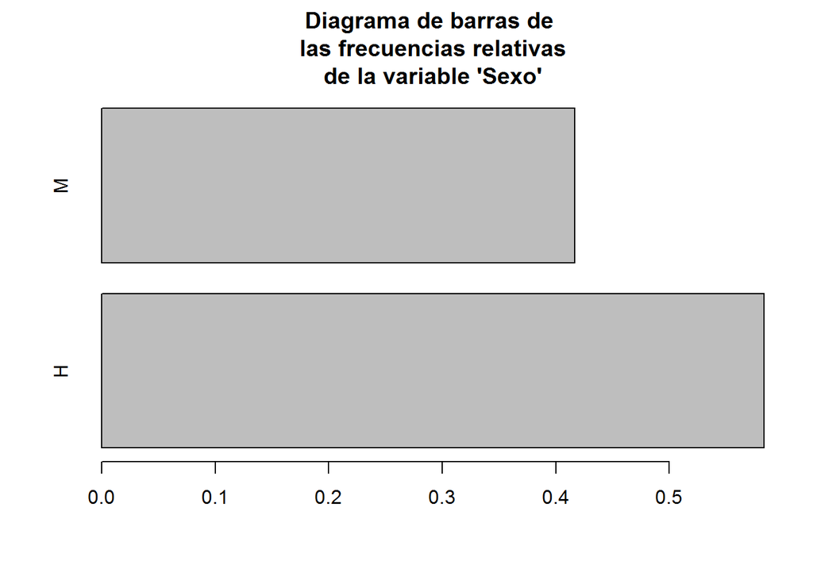

```r
Sex = factor(sample(c("H","M"), 12, replace = TRUE))
barplot(prop.table(table(Sex)), main ="Diagrama de barras de\n las frecuencias relativas\n de la variable 'Sexo'", horiz = TRUE)
```

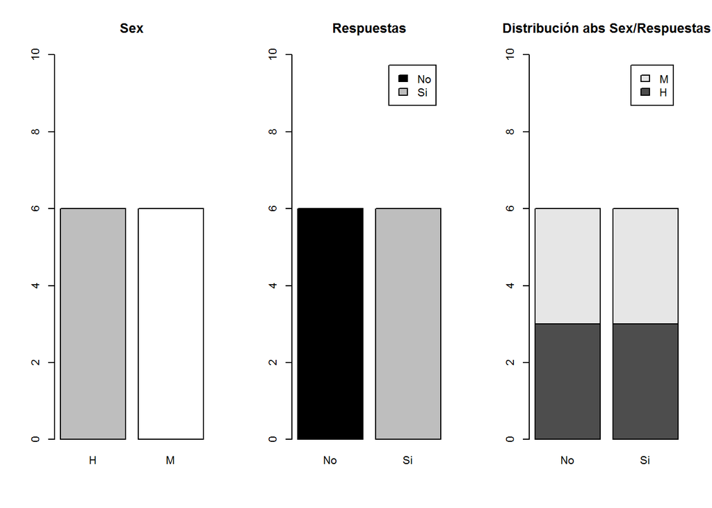

```r
Respuestas = factor(sample(c('Si', 'No'), size=12, replace = TRUE))
Sex = factor(sample(c("H","M"), size = 12, replace = TRUE))

par(mfrow = c(1,3))
barplot(table(Sex),col = c('gray','white'), ylim = c(0,10), main ="Sex")
barplot(table(Respuestas), col = c('black', 'gray'),ylim = c(0,10), legend.text = T, main = "Respuestas")
barplot(table(Sex, Respuestas),ylim = c(0,10), legend.text = T, main = "Distribución abs Sex/Respuestas")
```

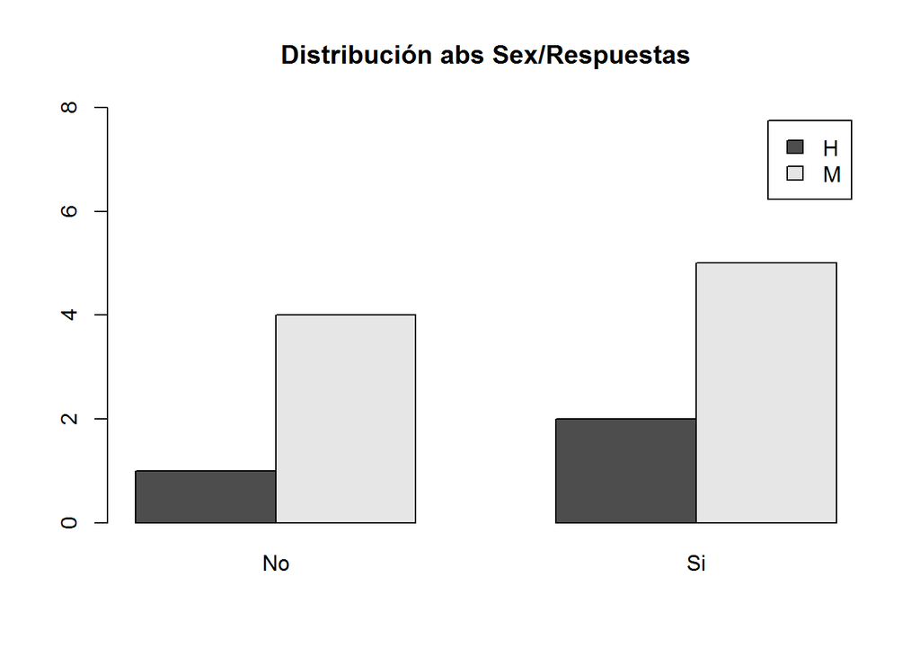

```r
Respuestas = factor(sample(c('Si', 'No'), size=12, replace = TRUE))
Sex = factor(sample(c("H","M"), size = 12, replace = TRUE))


barplot(table(Sex, Respuestas),ylim = c(0,8), beside = T,legend.text = T, main = "Distribución abs Sex/Respuestas")
```

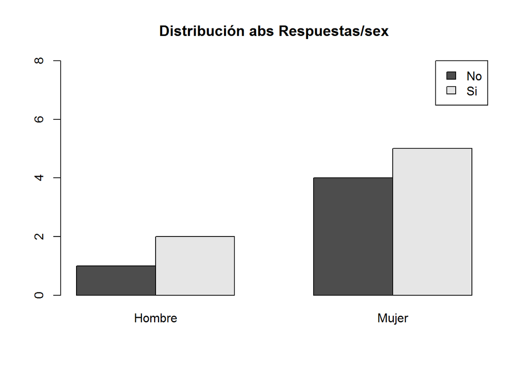

```r
barplot(table(Respuestas, Sex),ylim = c(0,8), names = c("Hombre", "Mujer") ,beside = T,legend.text = T, main = "Distribución abs Respuestas/sex", args.legend = list(x = 'topright'))
```

```r
barplot(height = cbind(x = c(465, 91) / 465 * 100,
                       y = c(840, 200) / 840 * 100,
                       z = c(37, 17) / 37 * 100),
        beside = FALSE,
        width = c(465, 840, 37),
        col = c(1, 2),
        legend.text = c("A", "B"),
        args.legend = list(x = "topleft"))
```

[output not shown]

# Diagrama circular

- Los **diagramas circulares** (o *pie chart*) se representan los niveles de una variable cualitativa como sectores de un círculo, de manera que el ángulo del círculo es proporcional a la frecuencia del nivel.
- Se aplica a una tabla de frecuencias y no al vector original.
- De difícil visualización. Es complicado comparar los niveles de la variable analizada

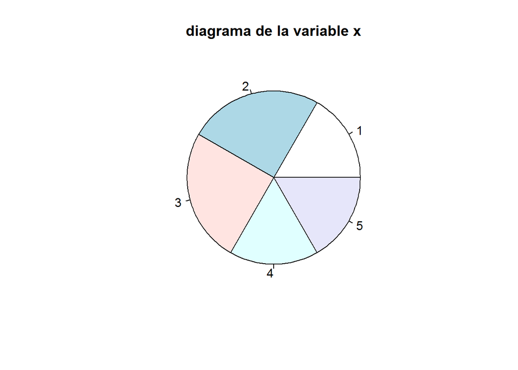

```r
x = c(4,2,3,5,1,4,3,1,5,2,3,2)
pie(table(x), main = "diagrama de la variable x")
```

# Gráficos de mosaico

En estos **gráficos de mosaico** se obtienen sustituyendo cada entrada de la tabla de frecuencias por una región rectangular de área proporcional a su valor.

```
- Complicado de leer cuando se agregan variables
```

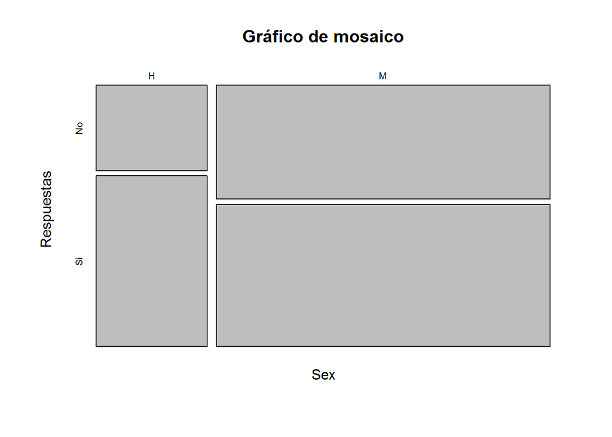

```r
plot(table(Sex, Respuestas), main ="Gráfico de mosaico")
```

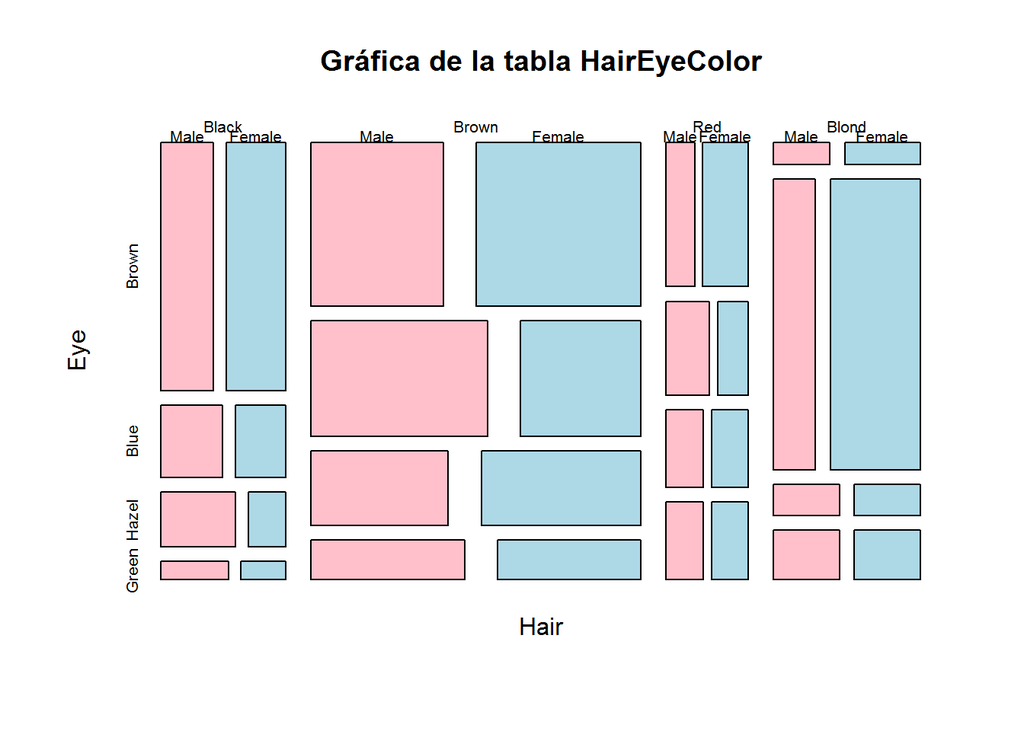

```r
plot(HairEyeColor, main = "Gráfica de la tabla HairEyeColor", col = c("pink", "lightblue"))
```